# Assignment_09

Author: Megan Xiao

Date: 2025-10-27

## Choose a Dataset

R packages contain various data sets for users to practice and work with. For this assignment, I chose the “storms” data set from the dplyr package. This data set contains ~19000 rows on storms with columns on wind speed, location, pressure, and more.  
We load the data set in with the data() function, specifying the name of the data set and the package it originates from. Then, we can analyze the first 6 rows using the head() function:

```r
data("storms", package = "dplyr")
head(storms)
```

```
##   name year month day hour  lat  long              status category wind
## 1  Amy 1975     6  27    0 27.5 -79.0 tropical depression       NA   25
## 2  Amy 1975     6  27    6 28.5 -79.0 tropical depression       NA   25
## 3  Amy 1975     6  27   12 29.5 -79.0 tropical depression       NA   25
## 4  Amy 1975     6  27   18 30.5 -79.0 tropical depression       NA   25
## 5  Amy 1975     6  28    0 31.5 -78.8 tropical depression       NA   25
## 6  Amy 1975     6  28    6 32.4 -78.7 tropical depression       NA   25
##   pressure tropicalstorm_force_diameter hurricane_force_diameter
## 1     1013                           NA                       NA
## 2     1013                           NA                       NA
## 3     1013                           NA                       NA
## 4     1013                           NA                       NA
## 5     1012                           NA                       NA
## 6     1012                           NA                       NA
```

## Base R Graphics

Base R provides users with basic visualization functions. Although limited, they are useful for general exploratory analysis.  
First, I explore the relationships between wind speed and pressure of all the storms. To do this, I use the plot() function, plotting pressure based on wind speed:

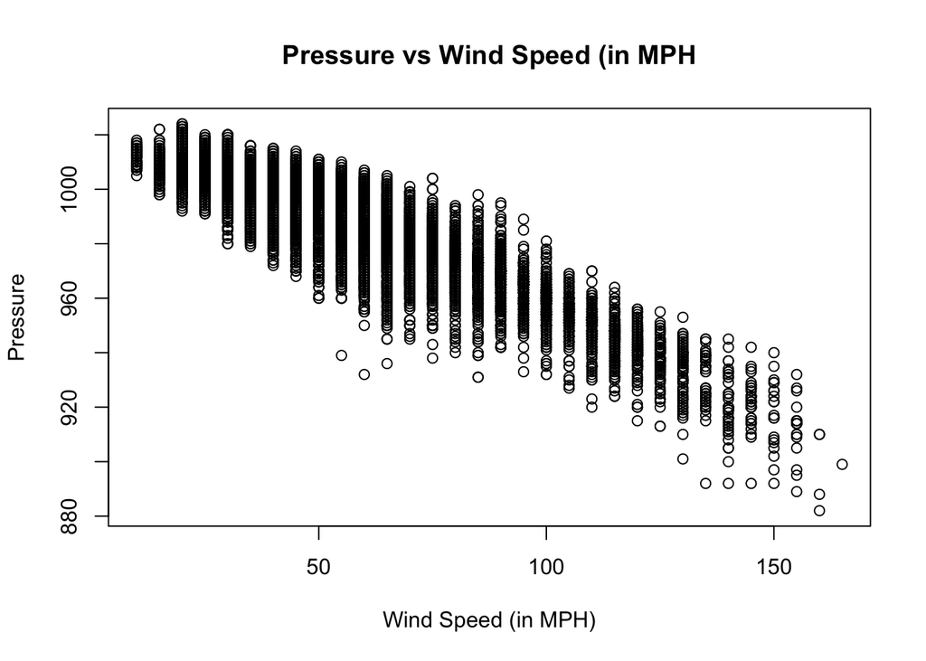

```r
plot(storms$pressure~ storms$wind,
     ylab = "Pressure",
     xlab = "Wind Speed (in MPH)",
     main = "Pressure vs Wind Speed (in MPH")
```

As wind speed increases, pressure decreases. This makes sense because changes in air density causes changes in pressure.  
Now, let’s observe the frequency of category 1-5 storms using a histogram:

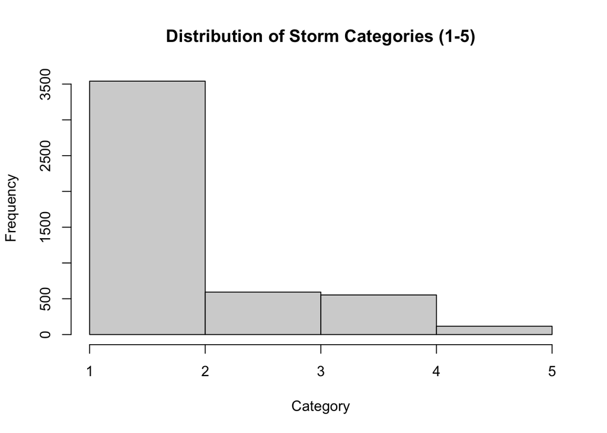

```r
hist(storms$category,
     breaks = 5,
     xlab = "Category",
     main = "Distribution of Storm Categories (1-5)")
```

Most storms are category 1 storms and the graph skews to the right. I was a bit surprised by this result, as I did not think category 2+ storms were rare compared to category 1 storms.

## Lattice Graphics

The lattice package, written by Deepayan Sarkar, enhances Base R graphs by improving visualizations of multivariate relationships. I will use the dplyr package to manipulate the data and lattice to create the visualizations.

```r
library(dplyr)
library(lattice)
library(latticeExtra)
```

After loading the two packages, I create a copy of the storms DataFrame so I can manipulate it without changing the original. Then, I use dplyr to create a new DataFrame from it. “s_avg_wind” contains the average wind speeds for each category 5 storm. Finally, I create a density plot with the densityplot() function, where the average wind speed is the x variable:

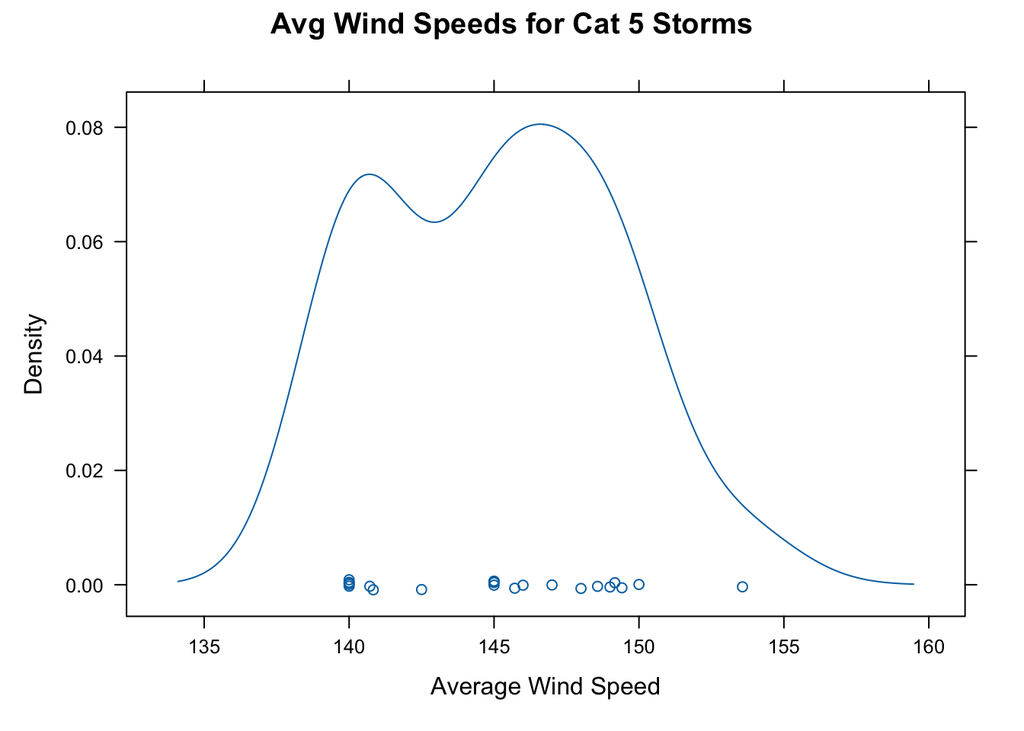

```r
s_df <- storms
s_avg_wind <- s_df %>%
  group_by(name) %>%
  filter(category == 5) %>%
  summarise(avg_wind_speed = mean(wind))

densityplot(~avg_wind_speed,data=s_avg_wind,
            xlab = "Average Wind Speed",
            main = "Avg Wind Speeds for Cat 5 Storms")
```

Most points cluster around the 140-150 mph area. There appears to be an outlier around 155. Most of these values are typical for a category 5 storm.  
Next, I analyze average wind speed and pressure of all storms by year. After grouping the storm data by year and creating columns for average wind speed and pressure, I used the levelplot() function to understand how average wind speed and pressure correlate as time changes.

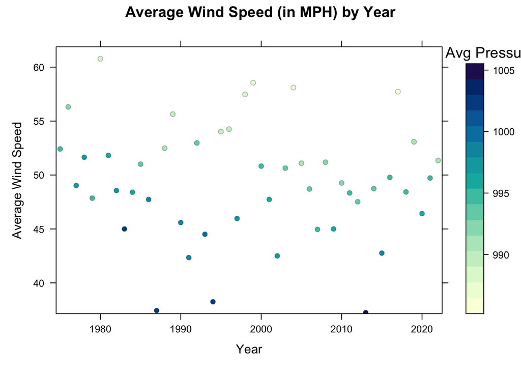

```r
s_pressure <- s_df %>%
  group_by(year) %>%
  summarise(avg_wind_speed = mean(wind), avg_pressure = mean(pressure))

levelplot(avg_pressure ~ year * avg_wind_speed,
          data = s_pressure,
          panel = panel.levelplot.points,
          xlab = "Year",
          ylab = "Average Wind Speed",
          main = "Average Wind Speed (in MPH) by Year",
          colorkey = list(title = "Avg Pressure",
                          title.control = list(side = "top"))
          )
```

```r
library(ggplot2)
```

```r
s_max <- s_df %>%
  group_by(name, year) %>%
  summarize(
    storm_length = n(),
    avg_wind = mean(wind),
    avg_pressure = mean(pressure)
  ) %>%
  arrange(desc(avg_wind))
```

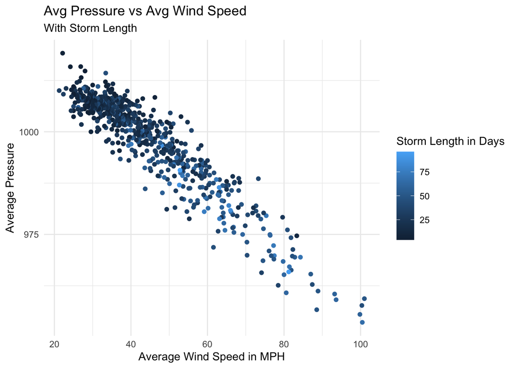

```r
ggplot(s_max, aes(x = avg_wind, y = avg_pressure, color=storm_length)) +
  geom_point() +
  labs(title = "Avg Pressure vs Avg Wind Speed",
       subtitle = "With Storm Length",
       x = "Average Wind Speed in MPH",
       y = "Average Pressure",
       color = "Storm Length in Days") +
  theme_minimal()
```

As wind speed increases and pressure decreases, storm length appears to increase. This may be due to the fact that when a storm has more time to develop, there is a higher likelihood it becomes a stronger storm.  
Finally, I compare the wind speeds of the 5 strongest storms based on max wind speeds. First, I obtain the storm names by grabbing the names with the highest wind speeds. Then I use those five names to filter for the rows containing those names, thus grabbing all wind speed data points for the top 5 strongest storms. I use ggplot() and geom_boxplot() to visualize how the 5 strongest storms differ in wind speeds:

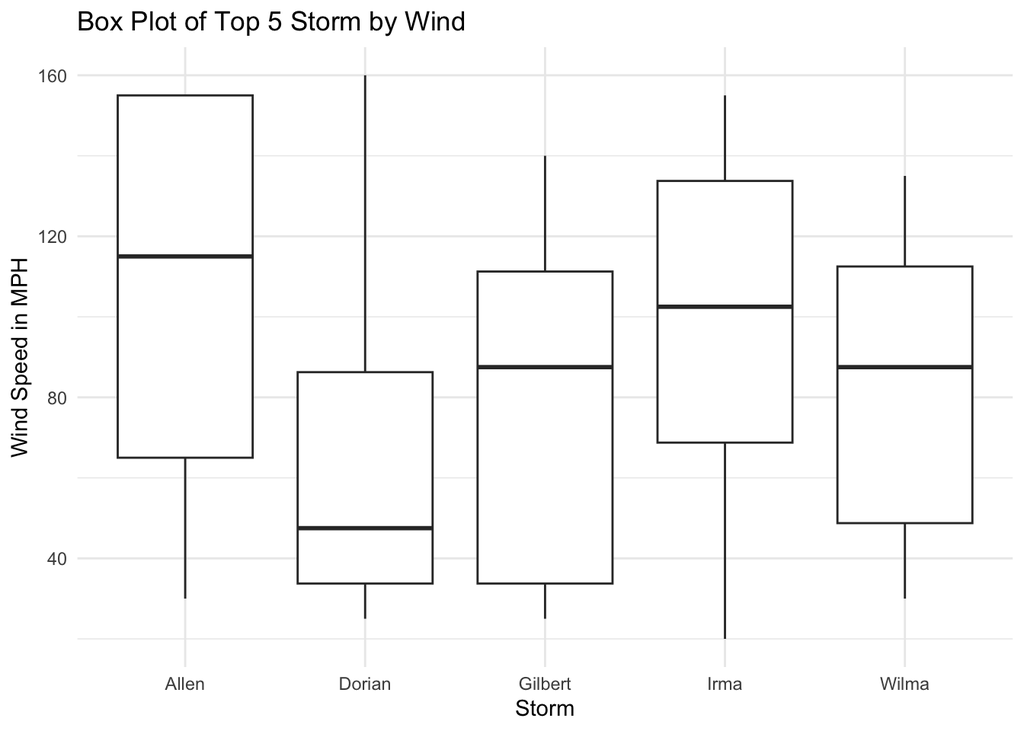

```r
#box plot of top 5 strongest storm by max winds
s_top_5_names <- s_df %>%
  group_by(name) %>%
  summarise(max_wind = max(wind)) %>%
  arrange(desc(max_wind)) %>%
  slice_head(n=5)

s_top_5 <- s_df %>%
  filter(name == s_top_5_names$name)
ggplot(s_top_5, aes(x = name, y = wind)) + geom_boxplot(outlier.color = "red") +
  labs(title = "Box Plot of Top 5 Storm by Wind",
       x = "Storm",
       y = "Wind Speed in MPH") +
  theme_minimal()
```

It appears Allen overall had the highest wind speeds while Dorian had the lowest.

## Discussion

Base R uses an additive model where you start with a plot window and layer elements using successive function calls. Lattice uses a single function call based on trellis graphics, which shows the relationship between multiple variables across different subsets of data. ggplot2 utilizes an additive approach to map data variables, aesthetic properties (aes), geometric shapes (geom), and scales and facets (facet_wrap or facet_grid).

In my opinion, ggplot2 provides the most control and produces “publication-quality” output. Although Base R offers more control, achieving high-quality aesthetics, such as various font themes, axis breaks, or complex legends, it requires a lot of manual tweaking. ggplot2 possesses a layered structure and theme system, allowing for more complex aesthetics without excessive effort.

Changing between ggplot2, lattice, and Base R and getting used to the syntax was the most challenging for me. Base R focuses on drawing one element at a time, lattice focuses uses tildes to draw multivariate graphs, and ggplot2 focuses on how variables are mapped onto graphs. I spent more time fixing errors in lattice and Base R, whereas ggplot2 automatically handled legends, color scales, and faceting for me.